# Speed Skating Analysis

# CREATE INTRODUCTORY VISUALIZATIONS TO UNDERSTAND THE DATA

```python
mdata['Finish Position'] = mdata['Rank']
wdata['Finish Position'] = wdata['Rank']

mdata['Medal'] = (mdata['Finish Position'] <= 3).astype(int)
wdata['Medal'] = (wdata['Finish Position'] <= 3).astype(int)
```

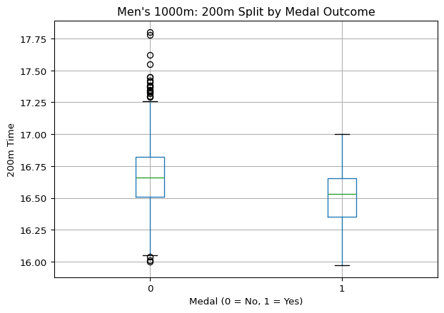

```python
# men's 200m split by medal outcome
import matplotlib.pyplot as plt
import seaborn as sns

mdata.boxplot(column='200m Time', by='Medal')
plt.title('Men\'s 1000m: 200m Split by Medal Outcome')
plt.suptitle('')
plt.xlabel('Medal (0 = No, 1 = Yes)')
plt.ylabel('200m Time')
plt.show()
```

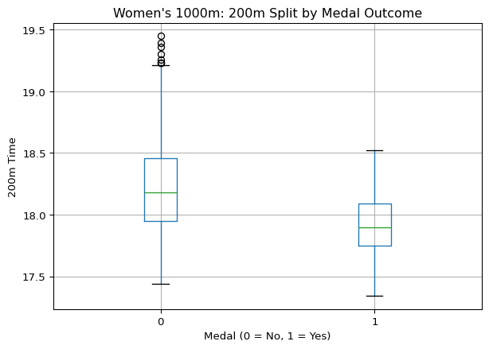

```python
# women's 200m split by medal outcome
import matplotlib.pyplot as plt
import seaborn as sns

wdata.boxplot(column='200m Time', by='Medal')
plt.title('Women\'s 1000m: 200m Split by Medal Outcome')
plt.suptitle('')
plt.xlabel('Medal (0 = No, 1 = Yes)')
plt.ylabel('200m Time')
plt.show()
```

# CREATE INTRODUCTORY LOGISTIC REGRESSION MODEL FOR MEDAL OUTCOMES

```python
# create senior / junior race counts
seniorm = mdata[mdata['Competition Level'] == 'Elite'].copy()
seniorw = wdata[wdata['Competition Level'] == 'Elite'].copy()
juniorm = mdata[mdata['Competition Level'] == 'Juniors'].copy()
juniorw = wdata[wdata['Competition Level'] == 'Juniors'].copy()
countseniorm = seniorm.groupby('Athlete ID').size()
countjuniorm = juniorm.groupby('Athlete ID').size()
countseniorw = seniorw.groupby('Athlete ID').size()
countjuniorw = juniorw.groupby('Athlete ID').size()

mdata['Senior Race Count'] = mdata['Athlete ID'].map(countseniorm).fillna(0).astype(int)
mdata['Junior Race Count'] = mdata['Athlete ID'].map(countjuniorm).fillna(0).astype(int)

wdata['Senior Race Count'] = wdata['Athlete ID'].map(countseniorw).fillna(0).astype(int)
wdata['Junior Race Count'] = wdata['Athlete ID'].map(countjuniorw).fillna(0).astype(int)
```

```python
men_model = mdata.dropna(subset=[
    'Medal',
    'Athlete Age (Days)',
    '200m Time',
    'Senior Race Count'
]).copy()
women_model = wdata.dropna(subset=[
    'Medal',
    'Athlete Age (Days)',
    '200m Time',
    'Senior Race Count'
]).copy()
women_model = wdata.dropna(subset=[
    'Medal',
    'Athlete Age (Days)',
    '200m Time',
    'Senior Race Count'
]).copy()

menx = men_model[['Athlete Age (Days)', '200m Time', 'Senior Race Count']]
meny = men_model['Medal']
womenx = women_model[['Athlete Age (Days)', '200m Time', 'Senior Race Count']]
womeny = women_model['Medal']
```

```python
# men's introductory logistic regression model
from sklearn.linear_model import LogisticRegression
from sklearn.model_selection import train_test_split
from sklearn.metrics import accuracy_score, confusion_matrix, roc_auc_score

xtrainm, xtestm, ytrainm, ytestm = train_test_split(
    menx, meny, test_size=0.2, random_state=42)

from sklearn.preprocessing import StandardScaler

scaler = StandardScaler()

xtrainm = scaler.fit_transform(xtrainm)
xtestm = scaler.transform(xtestm)

mlogit = LogisticRegression(max_iter=1000)
mlogit.fit(xtrainm, ytrainm)

menpred = mlogit.predict(xtestm)
menprob = mlogit.predict_proba(xtestm)[:, 1]

print("Men\'s Accuracy:", accuracy_score(ytestm, menpred))
print("Men\'s Confusion Matrix:\n", confusion_matrix(ytestm, menpred))
print("Men\'s ROC AUC:", roc_auc_score(ytestm, menprob))
```

```
Men's Accuracy: 0.8412017167381974
Men's Confusion Matrix:
 [[188   3]
 [ 34   8]]
Men's ROC AUC: 0.8484168536524558
```

```python
pd.DataFrame({
    'Variable': menx.columns,
    'Coefficient': mlogit.coef_[0]
}).sort_values('Coefficient', key=abs, ascending=False)
```

|  | Variable | Coefficient |
| --- | --- | --- |
| 2 | Senior Race Count | 0.872918 |
| 1 | 200m Time | -0.856065 |
| 0 | Athlete Age (Days) | -0.318801 |

```python
# women's introductory logistic regression model
xtrainw, xtestw, ytrainw, ytestw = train_test_split(
    womenx, womeny, test_size=0.2, random_state=42)

xtrainw = scaler.fit_transform(xtrainw)
xtestw = scaler.transform(xtestw)
wlogit = LogisticRegression(max_iter=1000)
wlogit.fit(xtrainw, ytrainw)

womenpred = wlogit.predict(xtestw)
womenprob = wlogit.predict_proba(xtestw)[:, 1]

print("Women\'s Accuracy:", accuracy_score(ytestw, womenpred))
print("Women\'s Confusion Matrix:\n", confusion_matrix(ytestw, womenpred))
print("Women\'s ROC AUC:", roc_auc_score(ytestw, womenprob))
```

```
Women's Accuracy: 0.8565217391304348
Women's Confusion Matrix:
 [[188   6]
 [ 27   9]]
Women's ROC AUC: 0.8353379152348225
```

```python
pd.DataFrame({
    'Variable': womenx.columns,
    'Coefficient': wlogit.coef_[0]
}).sort_values('Coefficient', key=abs, ascending=False)
```

|  | Variable | Coefficient |
| --- | --- | --- |
| 1 | 200m Time | -0.915104 |
| 2 | Senior Race Count | 0.691373 |
| 0 | Athlete Age (Days) | 0.155270 |

Both the women’s and men’s introductory logistic regression models performed strongly. The women’s model achieved a 85.65% accuracy score and a ROC AUC of 0.8353, indicating that 200m time, athlete age, and senior race count are potential predictors of medal outcomes.

# CREATE FEATURES AND DERIVED VARIABLES

```python
# ensure data is correctly sorted for feature creation
mdata = mdata.sort_values(['Athlete', 'Date']).copy()
wdata = wdata.sort_values(['Athlete', 'Date']).copy()
```

```python
# create feature for recent performance (last 3 senior races)
# raw value and z-score calculated to account for different race conditions
from scipy.stats import zscore
def last3m(mdata):
    mseniorrace = mdata[mdata['Competition Level'] == 'Elite'].copy()
    mseniorrace = mseniorrace.sort_values(['Athlete', 'Competition ID'])
    # z-score per race (accounts for different race conditions)
    mseniorrace['Result (Z-Score)'] = mseniorrace.groupby('Competition ID')['Result (Sec)'].transform(
        lambda x: zscore(x, ddof=1) if len(x) > 1 else 0.0)
    # rolling mean of last 3 races — raw finish time
    mseniorrace['Recent Performance (Raw)'] = mseniorrace.groupby('Athlete')['Result (Sec)'].transform(
        lambda x: x.shift(1).rolling(window=3, min_periods=1).mean())
    # rolling mean of last 3 races — z-score
    mseniorrace['Recent Performance (Z-Score)'] = mseniorrace.groupby('Athlete')['Result (Z-Score)'].transform(
        lambda x: x.shift(1).rolling(window=3, min_periods=1).mean())
    mseniorrace = mseniorrace.drop(columns=['Result (Z-Score)'])
    return mseniorrace

def last3w(wdata):
    wseniorrace = wdata[wdata['Competition Level'] == 'Elite'].copy()
    wseniorrace = wseniorrace.sort_values(['Athlete', 'Competition ID'])
    # z-score per race (accounts for different race conditions)
    wseniorrace['Result (Z-Score)'] = wseniorrace.groupby('Competition ID')['Result (Sec)'].transform(
        lambda x: zscore(x, ddof=1) if len(x) > 1 else 0.0)
    # rolling mean of last 3 races — raw finish time
    wseniorrace['Recent Performance (Raw)'] = wseniorrace.groupby('Athlete')['Result (Sec)'].transform(
        lambda x: x.shift(1).rolling(window=3, min_periods=1).mean())
    # rolling mean of last 3 races — z-score
    wseniorrace['Recent Performance (Z-Score)'] = wseniorrace.groupby('Athlete')['Result (Z-Score)'].transform(
        lambda x: x.shift(1).rolling(window=3, min_periods=1).mean())
    wseniorrace = wseniorrace.drop(columns=['Result (Z-Score)'])
    return wseniorrace
mdata = last3m(mdata)
wdata = last3w(wdata)
```

Here, a raw value, such as 68.81, represents an athlete’s average finish time over their last three races, while a value like -0.5 for the z-score indicates that the athlete’s average finish time over their last 3 races is half a standard deviation faster than the average finish time of all athletes. Negative values are faster than average, meaning an athlete with lower values performs better relative to the field. The shift ensures that the rolling window does not include the current race’s result to prevent data leakage.

```python
# create feature for personal best times
mdata['Personal Best'] = mdata.groupby('Athlete')['Result (Sec)'].transform('min')
wdata['Personal Best'] = wdata.groupby('Athlete')['Result (Sec)'].transform('min')
```

```python
# create feature for recent best times (2025 season)
seasonbestm = mdata[mdata['Date'].dt.year == 2025].groupby('Athlete')['Result (Sec)'].min()
mdata['Recent Best (2025)'] = mdata['Athlete'].map(seasonbestm)

seasonbestw = wdata[wdata['Date'].dt.year == 2025].groupby('Athlete')['Result (Sec)'].min()
wdata['Recent Best (2025)'] = wdata['Athlete'].map(seasonbestw)
```

```python
# create feature for average rank
mdata['Average Rank'] = mdata.groupby('Athlete')['Rank'].transform('mean')
wdata['Average Rank'] = wdata.groupby('Athlete')['Rank'].transform('mean')
```

```python
# create feature for average medal outcome
mdata['Average Medal Outcome'] = mdata.groupby('Athlete')['Medal'].transform('mean')
wdata['Average Medal Outcome'] = wdata.groupby('Athlete')['Medal'].transform('mean')

# filter athletes with an average medal outcome not equal to 0
athleteswithmedalsm = mdata[mdata['Average Medal Outcome'] != 0]

athleteswithmedalsw = wdata[wdata['Average Medal Outcome'] != 0]
```

```python
# create feature for season over season change in finish time
def seasonchangem(mdata):
    mdata = mdata.sort_values(['Athlete', 'Date']).copy()
    mdata['Season Over Season Change'] = mdata.groupby('Athlete')['Result (Sec)'].transform(lambda x: x.pct_change())
    return mdata

def seasonchangew(wdata):
    wdata = wdata.sort_values(['Athlete', 'Date']).copy()
    wdata['Season Over Season Change'] = wdata.groupby('Athlete')['Result (Sec)'].transform(lambda x: x.pct_change())
    return wdata
mdata = seasonchangem(mdata)
wdata = seasonchangew(wdata)
```

```python
# create feature for days since last race (as of February 6, 2026)
def dayssincelastm(mdata):
    mdata = mdata.sort_values(['Athlete', 'Date']).copy()
    mostrecentrace = mdata.groupby('Athlete')['Date'].max()
    dayssincelastrace = (pd.Timestamp('2026-02-06') - mostrecentrace).dt.days
    return mdata['Athlete'].map(dayssincelastrace)

def dayssincelastw(wdata):
    wdata = wdata.sort_values(['Athlete', 'Date']).copy()
    mostrecentrace = wdata.groupby('Athlete')['Date'].max()
    dayssincelastrace = (pd.Timestamp('2026-02-06') - mostrecentrace).dt.days
    return wdata['Athlete'].map(dayssincelastrace)

mdata['Days Since Last Race'] = dayssincelastm(mdata)
wdata['Days Since Last Race'] = dayssincelastw(wdata)
```

```python
# create feature for time variation
mdata['Time Variation'] = mdata.groupby('Athlete')['Result (Sec)'].transform('std')

wdata['Time Variation'] = wdata.groupby('Athlete')['Result (Sec)'].transform('std')
```

# CREATE XGBOOST MODEL FOR MEDALS

```python
# define features to use in model
features = [
    'Athlete Age (Days)',
    '200m Time',
    '600m Time',
    'Senior Race Count',
    'Junior Race Count',
    'Personal Best',
    'Recent Best (2025)',
    'Average Rank',
    'Average Medal Outcome',
    'Recent Performance (Raw)',
    'Recent Performance (Z-Score)',
    'Season Over Season Change',
    'Days Since Last Race',
    'Time Variation']
```

```python
# build clean modeling datasets
modelm = mdata.dropna(subset=features + ['Medal']).copy()
modelw = wdata.dropna(subset=features + ['Medal']).copy()
```

```python
Xm = modelm[features]
ym = modelm['Medal']

Xw = modelw[features]
yw = modelw['Medal']
```

```python
def compute_weights(mdata, reference_date='2026-02-06', recency_strength=0.001):
    # senior races get weight of 2, junior races get weight of 1
    level_weight = np.where(mdata['Competition Level'] == 'Elite', 2.0, 1.0)
    # more recent races get higher weight using exponential decay
    days_ago = (pd.Timestamp(reference_date) - mdata['Date']).dt.days
    recency_weight = np.exp(-recency_strength * days_ago)
    return level_weight * recency_weight

def compute_weightsw(wdata, reference_date='2026-02-06', recency_strength=0.001):
    # senior races get weight of 2, junior races get weight of 1
    level_weight = np.where(wdata['Competition Level'] == 'Elite', 2.0, 1.0)
    # more recent races get higher weight using exponential decay
    days_ago = (pd.Timestamp(reference_date) - wdata['Date']).dt.days
    recency_weight = np.exp(-recency_strength * days_ago)
    return level_weight * recency_weight

modelm['Weight'] = compute_weights(modelm)
modelw['Weight'] = compute_weightsw(modelw)
```

```python
# split training and testing data
from sklearn.model_selection import train_test_split

X_train_m, X_test_m, y_train_m, y_test_m, w_train_m, w_test_m = train_test_split(
    Xm, ym, modelm['Weight'], test_size=0.2, random_state=42)

X_train_w, X_test_w, y_train_w, y_test_w, w_train_w, w_test_w = train_test_split(
    Xw, yw, modelw['Weight'], test_size=0.2, random_state=42)
```

```python
# train men's xgboost model
from xgboost import XGBClassifier
from sklearn.metrics import accuracy_score, confusion_matrix, roc_auc_score
xgbm = XGBClassifier(    n_estimators=105,
    max_depth=4,
    learning_rate=0.05,
    subsample=0.8,
    colsample_bytree=0.8,
    min_child_weight=5,
    random_state=42,
    eval_metric='logloss')
xgbm.fit(X_train_m, y_train_m, sample_weight=w_train_m)

m_pred = xgbm.predict(X_test_m)
m_prob = xgbm.predict_proba(X_test_m)[:, 1]

print("Men\'s XGBoost Accuracy:", accuracy_score(y_test_m, m_pred))
print("Men\'s XGBoost Confusion Matrix:\n", confusion_matrix(y_test_m, m_pred))
print("Men\'s XGBoost ROC AUC:", roc_auc_score(y_test_m, m_prob))
```

```
Men's XGBoost Accuracy: 0.8686868686868687
Men's XGBoost Confusion Matrix:
 [[76  3]
 [10 10]]
Men's XGBoost ROC AUC: 0.8987341772151899
```

```python
# men's feature importance
mimportance = pd.DataFrame({
    'Feature': features,
    'Importance': xgbm.feature_importances_
}).sort_values('Importance', ascending=False)
mimportance
```

|  | Feature | Importance |
| --- | --- | --- |
| 8 | Average Medal Outcome | 0.235752 |
| 7 | Average Rank | 0.216599 |
| 10 | Recent Performance (Z-Score) | 0.141215 |
| 1 | 200m Time | 0.071914 |
| 6 | Recent Best (2025) | 0.054120 |
| 13 | Time Variation | 0.044762 |
| 3 | Senior Race Count | 0.044329 |
| 5 | Personal Best | 0.043513 |
| 0 | Athlete Age (Days) | 0.040401 |
| 11 | Season Over Season Change | 0.039621 |
| 2 | 600m Time | 0.035023 |
| 9 | Recent Performance (Raw) | 0.032751 |
| 4 | Junior Race Count | 0.000000 |
| 12 | Days Since Last Race | 0.000000 |

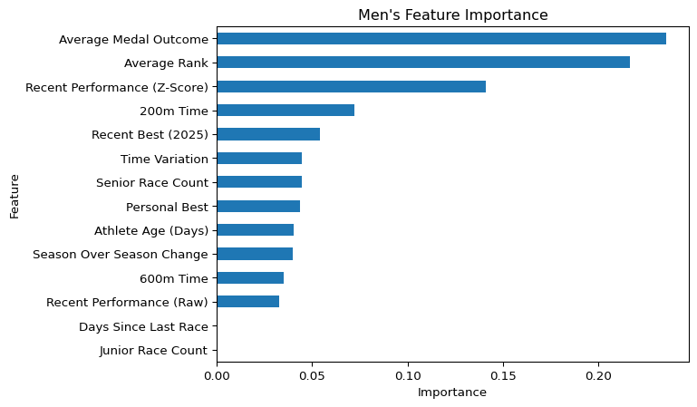

```python
# plot feature importance
import matplotlib.pyplot as plt

mimportance.sort_values('Importance').plot(
    kind='barh',
    x='Feature',
    y='Importance',
    legend=False)

plt.title('Men\'s Feature Importance')
plt.xlabel('Importance')
plt.ylabel('Feature')
plt.show()
```

```python
from xgboost import XGBClassifier
from sklearn.metrics import accuracy_score, confusion_matrix, roc_auc_score
xgbw = XGBClassifier(    n_estimators=105,
    max_depth=4,
    learning_rate=0.05,
    subsample=0.8,
    colsample_bytree=0.8,
    min_child_weight=5,
    random_state=42,
    eval_metric='logloss')
xgbw.fit(X_train_w, y_train_w, sample_weight=w_train_w)

w_pred = xgbw.predict(X_test_w)
w_prob = xgbw.predict_proba(X_test_w)[:, 1]

print("Women\'s XGBoost Accuracy:", accuracy_score(y_test_w, w_pred))
print("Women\'s XGBoost Confusion Matrix:\n", confusion_matrix(y_test_w, w_pred))
print("Women\'s XGBoost ROC AUC:", roc_auc_score(y_test_w, w_prob))
```

```
Women's XGBoost Accuracy: 0.8857142857142857
Women's XGBoost Confusion Matrix:
 [[74  6]
 [ 6 19]]
Women's XGBoost ROC AUC: 0.8995
```

```python
# women'sfeature importance
wimportance = pd.DataFrame({
    'Feature': features,
    'Importance': xgbw.feature_importances_
}).sort_values('Importance', ascending=False)
wimportance
```

|  | Feature | Importance |
| --- | --- | --- |
| 8 | Average Medal Outcome | 0.242292 |
| 10 | Recent Performance (Z-Score) | 0.194757 |
| 5 | Personal Best | 0.154181 |
| 7 | Average Rank | 0.074120 |
| 2 | 600m Time | 0.063121 |
| 1 | 200m Time | 0.049712 |
| 6 | Recent Best (2025) | 0.045314 |
| 9 | Recent Performance (Raw) | 0.039048 |
| 13 | Time Variation | 0.034695 |
| 12 | Days Since Last Race | 0.028974 |
| 11 | Season Over Season Change | 0.028142 |
| 0 | Athlete Age (Days) | 0.024541 |
| 3 | Senior Race Count | 0.021105 |
| 4 | Junior Race Count | 0.000000 |

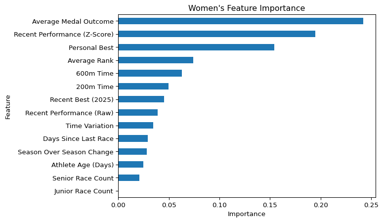

```python
# plot feature importance
import matplotlib.pyplot as plt

wimportance.sort_values('Importance').plot(
    kind='barh',
    x='Feature',
    y='Importance',
    legend=False)

plt.title('Women\'s Feature Importance')
plt.xlabel('Importance')
plt.ylabel('Feature')
plt.show()
```

# CREATE NEURAL NETWORK MODEL FOR MEDALS

```python
# define features to use in model
nnfeatures = [
    'Athlete Age (Days)',
    '200m Time',
    '600m Time',
    'Senior Race Count',
    'Junior Race Count',
    'Personal Best',
    'Recent Best (2025)',
    'Average Rank',
    'Average Medal Outcome',
    'Recent Performance (Raw)',
    'Recent Performance (Z-Score)',
    'Season Over Season Change',
    'Days Since Last Race',
    'Time Variation']
```

```python
from sklearn.model_selection import train_test_split
from sklearn.preprocessing import StandardScaler
from sklearn.neural_network import MLPClassifier
from sklearn.metrics import accuracy_score, confusion_matrix, roc_auc_score

mnn = mdata.dropna(subset=nnfeatures + ['Medal']).copy()

X_mnn = mnn[nnfeatures]
y_mnn = mnn['Medal']

xtrain_mnn, xtest_mnn, ytrain_mnn, ytest_mnn = train_test_split(
    X_mnn, y_mnn, test_size=0.2, random_state=42
)

scaler_mnn = StandardScaler()
xtrain_mnn = scaler_mnn.fit_transform(xtrain_mnn)
xtest_mnn = scaler_mnn.transform(xtest_mnn)

mlp_m = MLPClassifier(
    hidden_layer_sizes=(16, 8),
    activation='relu',
    solver='adam',
    alpha=0.001,
    max_iter=1000,
    random_state=42
)

mlp_m.fit(xtrain_mnn, ytrain_mnn)

m_nn_pred = mlp_m.predict(xtest_mnn)
m_nn_prob = mlp_m.predict_proba(xtest_mnn)[:, 1]

print("Men's NN Accuracy:", accuracy_score(ytest_mnn, m_nn_pred))
print("Men's NN Confusion Matrix:\n", confusion_matrix(ytest_mnn, m_nn_pred))
print("Men's NN ROC AUC:", roc_auc_score(ytest_mnn, m_nn_prob))
```

```
Men's NN Accuracy: 0.8787878787878788
Men's NN Confusion Matrix:
 [[76  3]
 [ 9 11]]
Men's NN ROC AUC: 0.8987341772151899
```

```
/Users/ashmarietta/Library/Mobile Documents/com~apple~CloudDocs/admin/usopc_app/usopc/lib/python3.11/site-packages/sklearn/neural_network/_multilayer_perceptron.py:785: ConvergenceWarning: Stochastic Optimizer: Maximum iterations (1000) reached and the optimization hasn't converged yet.
  warnings.warn(
```

```python
wnn = wdata.dropna(subset=nnfeatures + ['Medal']).copy()

X_wnn = wnn[nnfeatures]
y_wnn = wnn['Medal']

xtrain_wnn, xtest_wnn, ytrain_wnn, ytest_wnn = train_test_split(
    X_wnn, y_wnn, test_size=0.2, random_state=42
)

scaler_wnn = StandardScaler()
xtrain_wnn = scaler_wnn.fit_transform(xtrain_wnn)
xtest_wnn = scaler_wnn.transform(xtest_wnn)

mlp_w = MLPClassifier(
    hidden_layer_sizes=(16, 8),
    activation='relu',
    solver='adam',
    alpha=0.001,
    max_iter=1000,
    random_state=42
)

mlp_w.fit(xtrain_wnn, ytrain_wnn)

w_nn_pred = mlp_w.predict(xtest_wnn)
w_nn_prob = mlp_w.predict_proba(xtest_wnn)[:, 1]

print("Women's NN Accuracy:", accuracy_score(ytest_wnn, w_nn_pred))
print("Women's NN Confusion Matrix:\n", confusion_matrix(ytest_wnn, w_nn_pred))
print("Women's NN ROC AUC:", roc_auc_score(ytest_wnn, w_nn_prob))
```

```
Women's NN Accuracy: 0.8571428571428571
Women's NN Confusion Matrix:
 [[73  7]
 [ 8 17]]
Women's NN ROC AUC: 0.9219999999999999
```

# UPDATE LOGISTIC REGRESSION MODEL WITH NEW FEATURES FOR MEDALS

```python
from sklearn.linear_model import LogisticRegression
from sklearn.preprocessing import StandardScaler

scaler_m = StandardScaler()
X_train_m_scaled = scaler_m.fit_transform(X_train_m)
X_test_m_scaled = scaler_m.transform(X_test_m)

mlogit = LogisticRegression(max_iter=1000)
mlogit.fit(X_train_m_scaled, y_train_m)

menpred = mlogit.predict(X_test_m_scaled)
menprob = mlogit.predict_proba(X_test_m_scaled)[:, 1]

print("Men's Logistic Accuracy:", accuracy_score(y_test_m, menpred))
print("Men's Logistic Confusion Matrix:\n", confusion_matrix(y_test_m, menpred))
print("Men's Logistic ROC AUC:", roc_auc_score(y_test_m, menprob))
```

```
Men's Logistic Accuracy: 0.8686868686868687
Men's Logistic Confusion Matrix:
 [[76  3]
 [10 10]]
Men's Logistic ROC AUC: 0.9189873417721519
```

```python
scaler_w = StandardScaler()
X_train_w_scaled = scaler_w.fit_transform(X_train_w)
X_test_w_scaled = scaler_w.transform(X_test_w)

wlogit = LogisticRegression(max_iter=1000)
wlogit.fit(X_train_w_scaled, y_train_w)

womenpred = wlogit.predict(X_test_w_scaled)
womenprob = wlogit.predict_proba(X_test_w_scaled)[:, 1]

print("Women's Logistic Accuracy:", accuracy_score(y_test_w, womenpred))
print("Women's Logistic Confusion Matrix:\n", confusion_matrix(y_test_w, womenpred))
print("Women's Logistic ROC AUC:", roc_auc_score(y_test_w, womenprob))
```

```
Women's Logistic Accuracy: 0.8857142857142857
Women's Logistic Confusion Matrix:
 [[76  4]
 [ 8 17]]
Women's Logistic ROC AUC: 0.9304999999999999
```

# COMPARE MEDAL PREDICTION MODELS

```python
from sklearn.metrics import accuracy_score, roc_auc_score, confusion_matrix, precision_score, recall_score, f1_score
import pandas as pd
mresults = pd.DataFrame({
    'Model': ['Logistic Regression', 'XGBoost', 'Neural Network'],
    'Accuracy': [
        accuracy_score(y_test_m, menpred),
        accuracy_score(y_test_m, m_pred),
        accuracy_score(y_test_m, m_nn_pred)
    ],
    'ROC AUC': [
        roc_auc_score(y_test_m, menprob),
        roc_auc_score(y_test_m, m_prob),
        roc_auc_score(y_test_m, m_nn_prob)
    ],
    'Precision': [
        precision_score(y_test_m, menpred),
        precision_score(y_test_m, m_pred),
        precision_score(y_test_m, m_nn_pred)
    ],
    'Recall': [
        recall_score(y_test_m, menpred),
        recall_score(y_test_m, m_pred),
        recall_score(y_test_m, m_nn_pred)
    ],
    'F1 Score': [
        f1_score(y_test_m, menpred),
        f1_score(y_test_m, m_pred),
        f1_score(y_test_m, m_nn_pred)
    ]
})

mresults = mresults.sort_values(
    by=['ROC AUC', 'F1 Score'],
    ascending=[False, False])
mresults
```

|  | Model | Accuracy | ROC AUC | Precision | Recall | F1 Score |
| --- | --- | --- | --- | --- | --- | --- |
| 0 | Logistic Regression | 0.868687 | 0.918987 | 0.769231 | 0.50 | 0.606061 |
| 2 | Neural Network | 0.878788 | 0.898734 | 0.785714 | 0.55 | 0.647059 |
| 1 | XGBoost | 0.868687 | 0.898734 | 0.769231 | 0.50 | 0.606061 |

For the men’s models, it appears that the Logistic Regression model performed best with a ROC AUC of 0.9190, followed by the Neural Network with a ROC AUC of 0.8987. Finally, the XGBoost model also had a ROC AUC of 0.8987 but with a lower F1 Score than the Neural Network.

```python
wresults = pd.DataFrame({
    'Model': ['Logistic Regression', 'XGBoost', 'Neural Network'],
    'Accuracy': [
        accuracy_score(y_test_w, womenpred),
        accuracy_score(y_test_w, w_pred),
        accuracy_score(y_test_w, w_nn_pred)
    ],
    'ROC AUC': [
        roc_auc_score(y_test_w, womenprob),
        roc_auc_score(y_test_w, w_prob),
        roc_auc_score(y_test_w, w_nn_prob)
    ],
    'Precision': [
        precision_score(y_test_w, womenpred),
        precision_score(y_test_w, w_pred),
        precision_score(y_test_w, w_nn_pred)
    ],
    'Recall': [
        recall_score(y_test_w, womenpred),
        recall_score(y_test_w, w_pred),
        recall_score(y_test_w, w_nn_pred)
    ],
    'F1 Score': [
        f1_score(y_test_w, womenpred),
        f1_score(y_test_w, w_pred),
        f1_score(y_test_w, w_nn_pred)
    ]
})

wresults = wresults.sort_values(
    by=['ROC AUC', 'F1 Score'],
    ascending=[False, False])
wresults
```

|  | Model | Accuracy | ROC AUC | Precision | Recall | F1 Score |
| --- | --- | --- | --- | --- | --- | --- |
| 0 | Logistic Regression | 0.885714 | 0.9305 | 0.809524 | 0.68 | 0.739130 |
| 2 | Neural Network | 0.857143 | 0.9220 | 0.708333 | 0.68 | 0.693878 |
| 1 | XGBoost | 0.885714 | 0.8995 | 0.760000 | 0.76 | 0.760000 |

These models are predictive of medal outcomes based on historical performance data, but they do not directly calculate odds of the athletes with the top 3 finishing times in the Olympics. In the next section, I will estimate the odds of winning a medal for each athlete based on their predicted probability. I will use publicly-available data to determine the constraints for entering the games. For instance, each country can enter a maximum of 3 athletes, and there can only be up to 30 total participants in the 1000m event. Finally, each athlete must meet the qualifying time between August 1, 2025 and January 18, 2026 to be eligible for the Olympics, per the ISU Speed Skating Qualification System.

# CREATE TIME-BASED XGBOOST MODEL

```python
from sklearn.model_selection import train_test_split
from sklearn.metrics import mean_squared_error, mean_absolute_error
from xgboost import XGBRegressor
import numpy as np
tfeatures = [
    'Athlete Age (Days)',
    '200m Time',
    '600m Time',
    'Senior Race Count',
    'Junior Race Count',
    'Personal Best',
    'Recent Best (2025)',
    'Recent Performance (Raw)',
    'Recent Performance (Z-Score)',
    'Average Rank',
    'Average Medal Outcome',
    'Season Over Season Change',
    'Days Since Last Race',
    'Time Variation']
```

```python
regmodelm = mdata.dropna(subset=tfeatures + ['Result (Sec)']).copy()
regmodelw = wdata.dropna(subset=tfeatures + ['Result (Sec)']).copy()

X_reg_m = regmodelm[tfeatures]
y_reg_m = regmodelm['Result (Sec)']

X_reg_w = regmodelw[tfeatures]
y_reg_w = regmodelw['Result (Sec)']
```

```python
# weights for elite races and more recent races
def compute_reg_weights(mdata, reference_date='2026-02-06', recency_strength=0.001):
    level_weight = np.where(mdata['Competition Level'] == 'Elite', 2.0, 1.0)
    days_ago = (pd.Timestamp(reference_date) - mdata['Date']).dt.days
    recency_weight = np.exp(-recency_strength * days_ago)
    return level_weight * recency_weight

def compute_reg_weightsw(wdata, reference_date='2026-02-06', recency_strength=0.001):
    level_weight = np.where(wdata['Competition Level'] == 'Elite', 2.0, 1.0)
    days_ago = (pd.Timestamp(reference_date) - wdata['Date']).dt.days
    recency_weight = np.exp(-recency_strength * days_ago)
    return level_weight * recency_weight

regmodelm['Weight'] = compute_reg_weights(regmodelm)
regmodelw['Weight'] = compute_reg_weightsw(regmodelw)
```

```python
# split training and testing data
X_train_reg_m, X_test_reg_m, y_train_reg_m, y_test_reg_m, w_train_reg_m, w_test_reg_m = train_test_split(
    X_reg_m, y_reg_m, regmodelm['Weight'], test_size=0.25, random_state=42)

X_train_reg_w, X_test_reg_w, y_train_reg_w, y_test_reg_w, w_train_reg_w, w_test_reg_w = train_test_split(
    X_reg_w, y_reg_w, regmodelw['Weight'], test_size=0.25, random_state=42)
```

```python
# train men's finish time model
xgbrm = XGBRegressor(
    n_estimators=300,
    max_depth=3,
    learning_rate=0.05,
    subsample=0.7,
    reg_alpha=0.15,
    reg_lambda=1.25,
    colsample_bytree=0.7,
    min_child_weight=9,
    random_state=42)

xgbrm.fit(X_train_reg_m, y_train_reg_m, sample_weight=w_train_reg_m)

m_time_pred = xgbrm.predict(X_test_reg_m)

m_rmse = np.sqrt(mean_squared_error(y_test_reg_m, m_time_pred))
m_mae = mean_absolute_error(y_test_reg_m, m_time_pred)

print("Men's Finish Time RMSE:", m_rmse)
print("Men's Finish Time MAE:", m_mae)
```

```
Men's Finish Time RMSE: 0.3661298399565799
Men's Finish Time MAE: 0.29988907728737907
```

```python
# compare training and testing error
m_train_pred = xgbrm.predict(X_train_reg_m)
train_rmse = np.sqrt(mean_squared_error(y_train_reg_m, m_train_pred))
print(f"Train RMSE: {train_rmse:.4f} | Test RMSE: {m_rmse:.4f}")
```

```
Train RMSE: 0.2207 | Test RMSE: 0.3661
```

```python
# train women's finish time model
xgbrw = XGBRegressor(
    n_estimators=300,
    max_depth=3,
    learning_rate=0.05,
    subsample=0.75,
    reg_alpha=0.1,
    reg_lambda=1.25,
    colsample_bytree=0.7,
    min_child_weight=6,
    random_state=42)

xgbrw.fit(X_train_reg_w, y_train_reg_w, sample_weight=w_train_reg_w)

w_time_pred = xgbrw.predict(X_test_reg_w)

w_rmse = np.sqrt(mean_squared_error(y_test_reg_w, w_time_pred))
w_mae = mean_absolute_error(y_test_reg_w, w_time_pred)

print("Women's Finish Time RMSE:", w_rmse)
print("Women's Finish Time MAE:", w_mae)
```

```
Women's Finish Time RMSE: 0.4051651300968573
Women's Finish Time MAE: 0.33018996842944953
```

```python
w_train_pred = xgbrw.predict(X_train_reg_w)
train_rmse = np.sqrt(mean_squared_error(y_train_reg_w, w_train_pred))
print(f"Train RMSE: {train_rmse:.4f} | Test RMSE: {w_rmse:.4f}")
```

```
Train RMSE: 0.3023 | Test RMSE: 0.4052
```

The gap between RMSE and MAE is relatively small in both models, suggesting that prediction errors are consistent and not overly influenced by large outliers. The model’s predictions are, on average, within about 0.3 to 0.4 seconds of actual finish times. While this level of error may seem meaningful in a sport where hundredths of a second can determine outcomes, it is acceptable for simulation purposes, as the model captures both central tendency and variability. This makes it well-suited for generating probabilistic medal forecasts when combined with the medal classification models.

# PREDICT ATHLETE TIMES

```python
# create one row per athlete with their most recent performance data to predict their finish time at the Olympics
predm = regmodelm.sort_values(['Athlete', 'Date']).groupby('Athlete').tail(1).copy()
predw = regmodelw.sort_values(['Athlete', 'Date']).groupby('Athlete').tail(1).copy()
```

```python
# predict finish time (mu)
predm['Mu'] = xgbrm.predict(predm[tfeatures])
predw['Mu'] = xgbrw.predict(predw[tfeatures])
```

```python
# fallback sigma from model residuals if time variation is missing
m_resid_sd = np.std(y_test_reg_m - m_time_pred)
w_resid_sd = np.std(y_test_reg_w - w_time_pred)

predm['Sigma'] = predm['Time Variation'].fillna(m_resid_sd)
predw['Sigma'] = predw['Time Variation'].fillna(w_resid_sd)

# keep sigma in a realistic range
predm['Sigma'] = predm['Sigma'].clip(lower=0.15, upper=1.50)
predw['Sigma'] = predw['Sigma'].clip(lower=0.15, upper=1.50)
```

```python
# apply Olympic qualification rules to filter athletes for medal probability simulation
qual_start = pd.Timestamp('2025-08-01')
qual_end = pd.Timestamp('2026-01-18')

qualm = regmodelm[(regmodelm['Date'] >= qual_start) & (regmodelm['Date'] <= qual_end)].copy()
qualw = regmodelw[(regmodelw['Date'] >= qual_start) & (regmodelw['Date'] <= qual_end)].copy()

qual_athletes_m = qualm['Athlete'].unique()
qual_athletes_w = qualw['Athlete'].unique()

predm_qual = predm[predm['Athlete'].isin(qual_athletes_m)].copy()
predw_qual = predw[predw['Athlete'].isin(qual_athletes_w)].copy()
```

```python
def simulate_race(mdata, n_sims=10000, random_state=42):
    np.random.seed(random_state)

    athletes = mdata['Athlete'].values
    countries = mdata['Country'].values
    mus = mdata['Mu'].values
    sigmas = mdata['Sigma'].values

    sim_times = np.random.normal(
        loc=mus[:, None],
        scale=sigmas[:, None],
        size=(len(mdata), n_sims))

    sim_df = pd.DataFrame(sim_times, index=athletes)

    gold_counts = pd.Series(0, index=athletes, dtype=float)
    silver_counts = pd.Series(0, index=athletes, dtype=float)
    bronze_counts = pd.Series(0, index=athletes, dtype=float)

    for i in range(n_sims):
        ranks = sim_df.iloc[:, i].rank(method='first')
        gold_counts += (ranks == 1)
        silver_counts += (ranks == 2)
        bronze_counts += (ranks == 3)

    results = mdata[['Athlete', 'Country', 'Gender', 'Mu', 'Sigma']].copy()
    results['Gold Probability'] = results['Athlete'].map(gold_counts / n_sims)
    results['Silver Probability'] = results['Athlete'].map(silver_counts / n_sims)
    results['Bronze Probability'] = results['Athlete'].map(bronze_counts / n_sims)
    results['Medal Probability'] = (
        results['Gold Probability'] +
        results['Silver Probability'] +
        results['Bronze Probability'])
    results['Gold Odds'] = results['Gold Probability'] / (1 - results['Gold Probability'])
    results['Silver Odds'] = results['Silver Probability'] / (1 - results['Silver Probability'])
    results['Bronze Odds'] = results['Bronze Probability'] / (1 - results['Bronze Probability'])
    results['Medal Odds'] = results['Medal Probability'] / (1 - results['Medal Probability'])

    return results.sort_values('Medal Probability', ascending=False)

msim_qual = simulate_race(predm_qual, n_sims=10000, random_state=42)
```

```python
# apply country-level cap (max 3 athletes per country)
msim_top3 = msim_qual.sort_values('Medal Probability', ascending=False).groupby('Country').head(3)
msim_final = msim_top3.sort_values('Medal Probability', ascending=False).head(30)
```

```python
final_predm = predm_qual[predm_qual['Athlete'].isin(msim_final['Athlete'])]

msim_final = simulate_race(final_predm)
msim_final.head(10)
```

|  | Athlete | Country | Gender | Mu | Sigma | Gold Probability | Silver Probability | Bronze Probability | Medal Probability | Gold Odds | Silver Odds | Bronze Odds | Medal Odds |
| --- | --- | --- | --- | --- | --- | --- | --- | --- | --- | --- | --- | --- | --- |
| 2327 | Jordan Stolz | USA | Men | 67.603134 | 1.151832 | 0.2296 | 0.1346 | 0.1032 | 0.4674 | 0.298027 | 0.155535 | 0.115076 | 0.877582 |
| 917 | Damian Zurek | POL | Men | 67.877197 | 1.048043 | 0.1470 | 0.1175 | 0.1030 | 0.3675 | 0.172333 | 0.133144 | 0.114827 | 0.581028 |
| 2220 | Joep Wennemars | NED | Men | 68.083031 | 1.018857 | 0.1010 | 0.0953 | 0.0897 | 0.2860 | 0.112347 | 0.105339 | 0.098539 | 0.400560 |
| 2108 | Jenning de Boo | NED | Men | 68.188217 | 1.022257 | 0.0794 | 0.0813 | 0.0879 | 0.2486 | 0.086248 | 0.088495 | 0.096371 | 0.330849 |
| 3589 | Marten Liiv | EST | Men | 68.273888 | 1.075116 | 0.0764 | 0.0852 | 0.0767 | 0.2383 | 0.082720 | 0.093135 | 0.083072 | 0.312853 |
| 2836 | Kim Min-Seok | HUN | Men | 68.288597 | 0.995344 | 0.0623 | 0.0762 | 0.0701 | 0.2086 | 0.066439 | 0.082485 | 0.075384 | 0.263584 |
| 3476 | Marek Kania | POL | Men | 68.284538 | 0.874041 | 0.0469 | 0.0654 | 0.0737 | 0.1860 | 0.049208 | 0.069976 | 0.079564 | 0.228501 |
| 3127 | Laurent Dubreuil | CAN | Men | 68.432922 | 1.011510 | 0.0504 | 0.0627 | 0.0627 | 0.1758 | 0.053075 | 0.066894 | 0.066894 | 0.213298 |
| 2979 | Kjeld Nuis | NED | Men | 68.311966 | 0.842657 | 0.0420 | 0.0613 | 0.0661 | 0.1694 | 0.043841 | 0.065303 | 0.070778 | 0.203949 |
| 810 | Conor McDermott-Mostowy | USA | Men | 68.821434 | 1.302109 | 0.0536 | 0.0484 | 0.0433 | 0.1453 | 0.056636 | 0.050862 | 0.045260 | 0.170001 |

In this process, I created one row per athlete (most recent/representative row), predicted finish time for each athlete (Mu), and defined performance variability (Sigma) using time variation. I then ran 10,000 simulations, ranked simulated times each run, and calculated medal probabilities and odds. These probabilities are based on the model’s predictions of finish times and the variability in those predictions, as well as the constraints of Olympic qualification and country-level caps.

From the men’s analysis, it appears that American Jordan Stolz has the highest predicted medal probability at 46.74% (odds of .8776), followed by Polish skater Damian Zurek and Dutch athlete Joep Wennemars.

```python
def simulate_racew(wdata, n_sims=10000, random_state=42):
    np.random.seed(random_state)

    athletes = wdata['Athlete'].values
    countries = wdata['Country'].values
    mus = wdata['Mu'].values
    sigmas = wdata['Sigma'].values

    sim_times = np.random.normal(
        loc=mus[:, None],
        scale=sigmas[:, None],
        size=(len(wdata), n_sims))

    sim_df = pd.DataFrame(sim_times, index=athletes)

    gold_counts = pd.Series(0, index=athletes, dtype=float)
    silver_counts = pd.Series(0, index=athletes, dtype=float)
    bronze_counts = pd.Series(0, index=athletes, dtype=float)

    for i in range(n_sims):
        ranks = sim_df.iloc[:, i].rank(method='first')
        gold_counts += (ranks == 1)
        silver_counts += (ranks == 2)
        bronze_counts += (ranks == 3)

    results = wdata[['Athlete', 'Country', 'Gender', 'Mu', 'Sigma']].copy()
    results['Gold Probability'] = results['Athlete'].map(gold_counts / n_sims)
    results['Silver Probability'] = results['Athlete'].map(silver_counts / n_sims)
    results['Bronze Probability'] = results['Athlete'].map(bronze_counts / n_sims)
    results['Medal Probability'] = (
        results['Gold Probability'] +
        results['Silver Probability'] +
        results['Bronze Probability'])
    results['Gold Odds'] = results['Gold Probability'] / (1 - results['Gold Probability'])
    results['Silver Odds'] = results['Silver Probability'] / (1 - results['Silver Probability'])
    results['Bronze Odds'] = results['Bronze Probability'] / (1 - results['Bronze Probability'])
    results['Medal Odds'] = results['Medal Probability'] / (1 - results['Medal Probability'])

    return results.sort_values('Medal Probability', ascending=False)

wsim_qual = simulate_racew(predw_qual, n_sims=10000, random_state=42)
```

```python
# apply country-level cap (max 3 athletes per country)
wsim_top3 = wsim_qual.sort_values('Medal Probability', ascending=False).groupby('Country').head(3)
wsim_final = wsim_top3.sort_values('Medal Probability', ascending=False).head(30)
```

```python
final_predw = predw_qual[predw_qual['Athlete'].isin(wsim_final['Athlete'])]
wsim_final = simulate_racew(final_predw)
wsim_final.head(10)
```

|  | Athlete | Country | Gender | Mu | Sigma | Gold Probability | Silver Probability | Bronze Probability | Medal Probability | Gold Odds | Silver Odds | Bronze Odds | Medal Odds |
| --- | --- | --- | --- | --- | --- | --- | --- | --- | --- | --- | --- | --- | --- |
| 2496 | Jutta Leerdam | NED | Women | 74.055336 | 1.243190 | 0.2566 | 0.1775 | 0.1223 | 0.5564 | 0.345171 | 0.215805 | 0.139341 | 1.254283 |
| 3896 | Miho Takagi | JPN | Women | 74.340050 | 1.369945 | 0.2046 | 0.1494 | 0.1159 | 0.4699 | 0.257229 | 0.175641 | 0.131094 | 0.886437 |
| 1292 | Femke Kok | NED | Women | 74.585274 | 1.484002 | 0.1689 | 0.1298 | 0.1008 | 0.3995 | 0.203225 | 0.149161 | 0.112100 | 0.665279 |
| 3521 | Marrit Fledderus | NED | Women | 74.969086 | 1.395435 | 0.1050 | 0.0985 | 0.0902 | 0.2937 | 0.117318 | 0.109262 | 0.099143 | 0.415829 |
| 3138 | Lea Sophie Scholz | GER | Women | 75.277321 | 1.171656 | 0.0450 | 0.0662 | 0.0760 | 0.1872 | 0.047120 | 0.070893 | 0.082251 | 0.230315 |
| 4123 | Natalia Czerwonka | POL | Women | 75.204430 | 1.040896 | 0.0384 | 0.0654 | 0.0780 | 0.1818 | 0.039933 | 0.069976 | 0.084599 | 0.222195 |
| 3187 | Lee Nahyun | KOR | Women | 75.590340 | 1.259749 | 0.0315 | 0.0501 | 0.0580 | 0.1396 | 0.032525 | 0.052742 | 0.061571 | 0.162250 |
| 639 | Brittany Bowe | USA | Women | 75.517036 | 1.161330 | 0.0309 | 0.0445 | 0.0513 | 0.1267 | 0.031885 | 0.046572 | 0.054074 | 0.145082 |
| 1224 | Erin Jackson | USA | Women | 75.762268 | 1.121412 | 0.0173 | 0.0293 | 0.0416 | 0.0882 | 0.017605 | 0.030184 | 0.043406 | 0.096732 |
| 4703 | Rio Yamada | JPN | Women | 75.928757 | 1.171991 | 0.0153 | 0.0268 | 0.0350 | 0.0771 | 0.015538 | 0.027538 | 0.036269 | 0.083541 |

For the women’s event, Dutch skater Jutta Leerdam has the highest predicted medal probability at 55.64% (odds of 1.2543), followed by Japanese skater Miho Takagi and Dutch athlete Femke Kok.